# VraiDevoir

Maxime Ory

01/10/2019

### Diversité dans les écoles américaines

Les données viennent de The Washington Post grâce à Kate Rabinowitz, Laura Meckler, et Armand Emamdjomeh.

Cette analyse utilise le Common Core of Data du National Center for Education Statistics (NCES). Les écoles privées, et écoles à distances, ont été exclue car le gouvernement n’a qu’un contrôle très limité sur elles. Les données utilisée sont celles de 1994-1995, les plus anciennes disponnibles qui soient suffisemment claire, ainsi que celle de 2016-2017 qui sont les plus récente disponnible lors de la mise en ligne de cette base.

La variable principale est la diversité, elle est classée en 3 catégories :

```
    Diverse : Le groupe racial dominant représente moins de 75% des élèves.

    Undiverse : Entre 75% et 90% des élèves font parti du groupe dominant.

    Extremely Undiverse : 90% ou plus des élèves appartiennent au groupe dominant.
```

La catégorie multiracial n’existait pas en 1995 et est donc difficile à mettre en place.

Varialble : Description

LEAID : Unique school id

LEA_NAME : School District Name

ST : State of school district

d_Locale_Txt : Type of school district, town, rural, city, suburban combined with distant, remote, fringe, small, midsize, large

SCHOOL_YEAR : School year (either 1994-1995 or 2016-2017)

AIAN : American indian and alaskan native proportion of student population

Asian : Asian proportion of student population

Black : Black proportion of student population

Hispanic : Hispanic proportion of student population

White : White proportion of student population

Multi : Multi-ethnic proportion of student population

Total : Total student body count

diverse : Diverse rating (Diverse, undiverse, extremely undiverse)

variance : the variance ratio

int_group : the level of integration, defined as “Highly integated”, “Somewhat integrated” and “Not integrated”

###En première étape il nous faut activer tidyverse, et importer les données :

```r
library(tidyverse)
df <- read_csv("https://raw.githubusercontent.com/rfordatascience/tidytuesday/master/data/2019/2019-09-24/school_diversity.csv") #On place les données dans df.
```

##Comment avoir un bref aperçu de notre base de données ?

```r
summary(df) #On observe notre base de données
```

```
##     LEAID             LEA_NAME              ST
##  Length:27944       Length:27944       Length:27944
##  Class :character   Class :character   Class :character
##  Mode  :character   Mode  :character   Mode  :character
##
##
##
##
##  d_Locale_Txt       SCHOOL_YEAR             AIAN
##  Length:27944       Length:27944       Min.   :  0.0000
##  Class :character   Class :character   1st Qu.:  0.0000
##  Mode  :character   Mode  :character   Median :  0.1566
##                                        Mean   :  2.7879
##                                        3rd Qu.:  0.6144
##                                        Max.   :100.0000
##
##      Asian              Black             Hispanic            White
##  Min.   : 0.00000   Min.   :  0.0000   Min.   :  0.0000   Min.   :  0.00
##  1st Qu.: 0.05818   1st Qu.:  0.2023   1st Qu.:  0.5505   1st Qu.: 65.24
##  Median : 0.53124   Median :  0.9231   Median :  2.7094   Median : 88.60
##  Mean   : 1.76956   Mean   :  6.5515   Mean   : 10.4520   Mean   : 76.93
##  3rd Qu.: 1.44514   3rd Qu.:  3.9649   3rd Qu.: 10.1256   3rd Qu.: 96.45
##  Max.   :74.90586   Max.   :100.0000   Max.   :100.0000   Max.   :100.00
##
##      Multi            Total           diverse             variance
##  Min.   : 0.000   Min.   :      1   Length:27944       Min.   :0.000
##  1st Qu.: 1.070   1st Qu.:    366   Class :character   1st Qu.:0.017
##  Median : 2.378   Median :   1044   Mode  :character   Median :0.046
##  Mean   : 3.202   Mean   :   3228                      Mean   :0.078
##  3rd Qu.: 4.174   3rd Qu.:   2720                      3rd Qu.:0.107
##  Max.   :85.308   Max.   :1020747                      Max.   :0.601
##  NA's   :14760                                         NA's   :24923
##   int_group
##  Length:27944
##  Class :character
##  Mode  :character
##
##
##
##
```

##Comment observer les différentes concentration d’éthnie dans un le système scolaire d’un état ? ##Comment comparer l’évolution de cette concentration au cours du temps ?

*Création d’un plot pour l’état de New York. On peut aisément modifier le filter afin d’obtenir ces résultats pour un autre état.*

```r
df_subNY <- df %>%
  filter(ST == "NY") %>% #On ne prend que les écoles dépendant de New York.
  select(SCHOOL_YEAR,ST,AIAN,Asian,Black,Hispanic,White) %>% #Seules certaines variables nous intéressent.
  group_by(SCHOOL_YEAR, ST) %>% #On veut Obtenir deux lignes, il faut que nos résultats dépendent de l'année, et de la zone des écoles.
  summarise_all(mean) %>% #On veut l'état d'une école moyenne, pas celui de chacune des écoles de NY.
  ungroup() %>%   #On annule la fonction group_by utilisée précédemment.
  gather(ethnicity, percent, -SCHOOL_YEAR, -ST) #Permet de présenter différement, on aura une ligne par Ethnie et par année, mettant ainsi en valeur l'évolution des pourcentages par années.
```

*Application du plot précédement créé à l’année 1994-1995.*

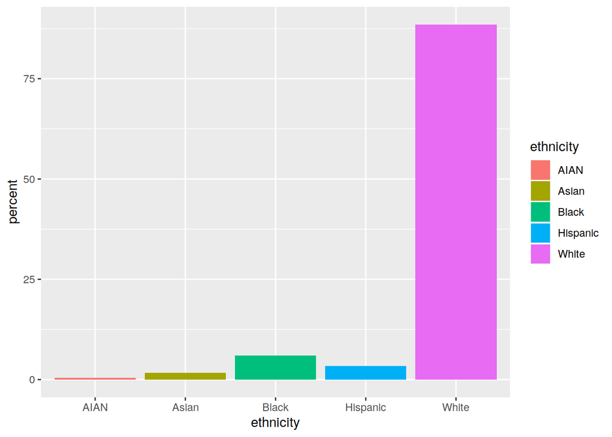

```r
plot_subNY_1994 <- df_subNY %>%
  filter(SCHOOL_YEAR == "1994-1995") %>% #On séléctionne l'année qu'on veut observer
  ggplot(aes(ethnicity, percent, fill = ethnicity))+ #Abcisse = Ehtnie, Ordonnée = Pourcentage de l'éthnie dans l'école moyenne de NY. Fill : Permet de mettre en valeur l'éthnie. (sinon tout noir.)
  geom_col() #geom_line n'est pas possible car on a qu'une seule observation.

plot_subNY_1994
```

*Application du plot précédement créé à l’année 2016-2017.*

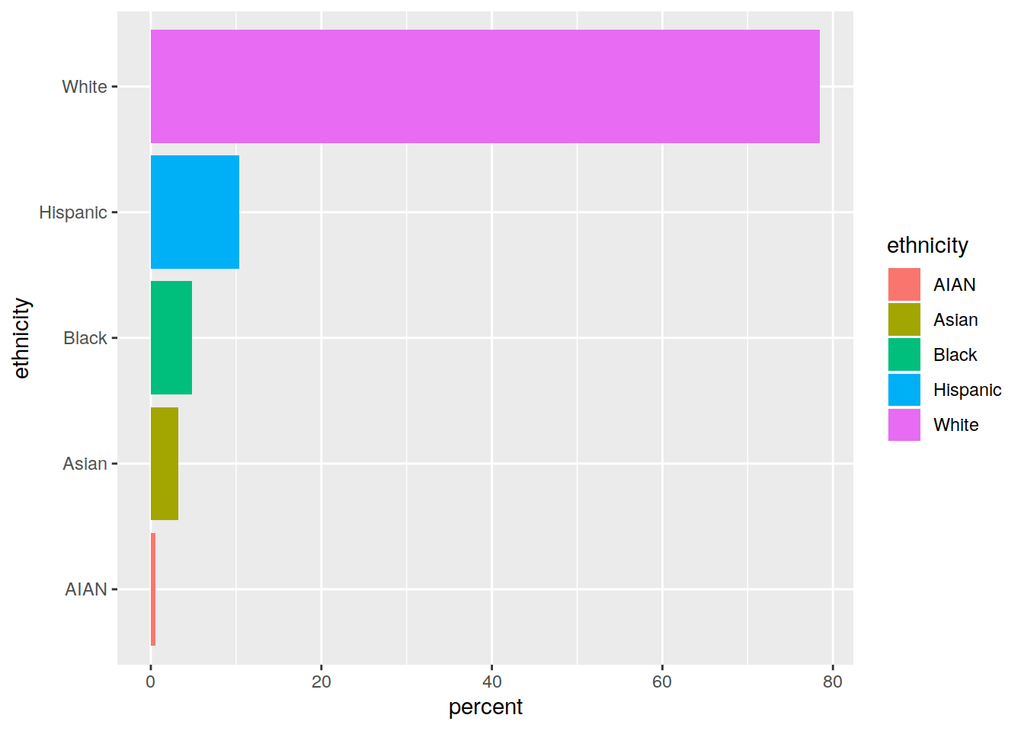

```r
plot_subNY_2016 <- df_subNY %>%
  filter(SCHOOL_YEAR == "2016-2017") %>%
  ggplot(aes(ethnicity, percent, fill = ethnicity))+
  geom_col()+
  coord_flip()

plot_subNY_2016
```

` ###Mettre en valeur la diversité dans les écoles dans un secteur au choix (Ville, village, périphérie ou campagne) et à une année au choix.

```r
df_alldiv <- df %>%
  filter(d_Locale_Txt == "town-distant"|d_Locale_Txt == "town-fringe"|d_Locale_Txt =="town-remote") %>% #Ici on ne veut prendre que les écoles de villages.
  select(d_Locale_Txt, Total, SCHOOL_YEAR, diverse) %>% #On ne veut pas toutes les variables.
  rename(id = d_Locale_Txt) %>% #On change le nom de la variable pour quelque chose de plus rapide.
  mutate(
    SCHOOL_YEAR = str_sub(SCHOOL_YEAR, 1, 4),  #str_sub nous permet ici de réduire la valeur "school_year" à 1994 au lieu de 1994-1995. On prend les éléments de 1 à 4 de la variable, à savoir : 1, 9, 9 et 4.
    diverse = fct_recode(diverse, "1" = "Diverse", "0" = "Undiverse", "-1" = "Extremely undiverse")) #fct_recode() permet de modifier le nom des paramètres de la variables.



df_alldiv
```

```
## # A tibble: 4,804 x 4
##    id           Total SCHOOL_YEAR diverse
##    <chr>        <dbl> <chr>       <fct>
##  1 town-distant  3118 1994        -1
##  2 town-distant  5447 2016        1
##  3 town-distant  2389 2016        1
##  4 town-distant  3788 1994        1
##  5 town-distant  3055 2016        1
##  6 town-remote   2091 1994        0
##  7 town-remote   1744 2016        1
##  8 town-fringe   2915 1994        1
##  9 town-fringe   3464 2016        1
## 10 town-distant  3539 1994        1
## # … with 4,794 more rows
```

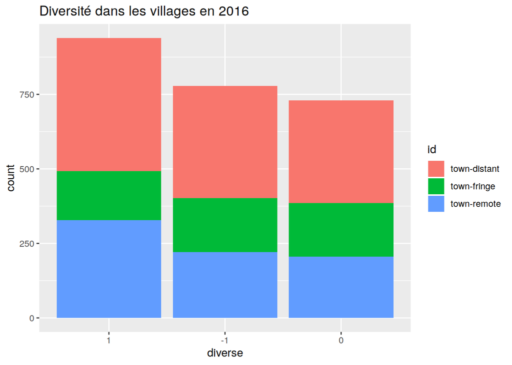

```r
plot_df_alldiv <- df_alldiv %>%
  filter(SCHOOL_YEAR == "2016") %>%
  ggplot(aes(diverse))+
  geom_bar(aes(fill = id))+
  # geom_text(aes())
  labs(title = "Diversité dans les villages en 2016")

plot_df_alldiv
```